# Preparing Mexico Data

```python
import pandas as pd
```

```python
# Load CSV files into DataFrames
df1 = pd.read_csv("C:/Users/x/Desktop/Housing-in-Mexico/mexico-real-estate-1.csv",sep=";", index_col=0)
df2 = pd.read_csv("C:/Users/x/Desktop/Housing-in-Mexico/mexico-real-estate-2.csv",sep=";", index_col=0)
df3 = pd.read_csv("C:/Users/x/Desktop/Housing-in-Mexico/mexico-real-estate-3.csv",sep=";", index_col=0)

# Print object type and shape for DataFrames
print("df1 type:", type(df1))
print("df1 shape:", df1.shape)
print()
print("df2 type:", type(df2))
print("df2 shape:", df2.shape)
print()
print("df3 type:", type(df3))
print("df3 shape:", df3.shape)
```

```
df1 type: <class 'pandas.core.frame.DataFrame'>
df1 shape: (700, 6)

df2 type: <class 'pandas.core.frame.DataFrame'>
df2 shape: (700, 6)

df3 type: <class 'pandas.core.frame.DataFrame'>
df3 shape: (700, 5)
```

Now that we have our three DataFrames, it's time to inspect them to see if they need any cleaning. Let's look at them one-by-one

```python
# Print df1 shap
df1.shape
# Print df1 info
df1.info()
# Get output of df1 head
df1.head()
```

```
<class 'pandas.core.frame.DataFrame'>
Index: 700 entries, 1 to 700
Data columns (total 6 columns):
 #   Column         Non-Null Count  Dtype
---  ------         --------------  -----
 0   property_type  700 non-null    object
 1   state          700 non-null    object
 2   lat            583 non-null    float64
 3   lon            583 non-null    float64
 4   area_m2        700 non-null    float64
 5   price_usd      700 non-null    object
dtypes: float64(3), object(3)
memory usage: 38.3+ KB
```

|  | property_type | state | lat | lon | area_m2 | price_usd |
| --- | --- | --- | --- | --- | --- | --- |
| 1 | house | Estado de México | 19.560181 | -99.233528 | 150.0 | $67,965.56 |
| 2 | house | Nuevo León | 25.688436 | -100.198807 | 186.0 | $63,223.78 |
| 3 | apartment | Guerrero | 16.767704 | -99.764383 | 82.0 | $84,298.37 |
| 4 | apartment | Guerrero | 16.829782 | -99.911012 | 150.0 | $94,308.80 |
| 5 | house | Veracruz de Ignacio de la Llave | NaN | NaN | 175.0 | $94,835.67 |

It looks like there are a couple of problems in this DataFrame that we need to solve. First, there are many rows with `NaN` values in the `"lat"` and `"lon"` columns. Second, the data type for the `"price_usd"` column is `object` when it should be `float`.

```python
# Drop null values from df1
df1.dropna(inplace=True)

# Clean "price_usd" column in df1
df1["price_usd"] = df1["price_usd"].str.replace("$","")
df1["price_usd"] = df1["price_usd"].str.replace(",","").astype(float)

# Print object type, shape, and head
print("df1 type:", type(df1))
print("df1 shape:", df1.shape)
df1.head()
```

```
df1 type: <class 'pandas.core.frame.DataFrame'>
df1 shape: (583, 6)
```

|  | property_type | state | lat | lon | area_m2 | price_usd |
| --- | --- | --- | --- | --- | --- | --- |
| 1 | house | Estado de México | 19.560181 | -99.233528 | 150.0 | 67965.56 |
| 2 | house | Nuevo León | 25.688436 | -100.198807 | 186.0 | 63223.78 |
| 3 | apartment | Guerrero | 16.767704 | -99.764383 | 82.0 | 84298.37 |
| 4 | apartment | Guerrero | 16.829782 | -99.911012 | 150.0 | 94308.80 |
| 6 | house | Yucatán | 21.052583 | -89.538639 | 205.0 | 105191.37 |

## Clean df2

```python
# Print df1 shap
df2.shape
# Print df1 info
df2.info()
# Get output of df1 head
df2.head()
```

```
<class 'pandas.core.frame.DataFrame'>
Index: 700 entries, 1 to 700
Data columns (total 6 columns):
 #   Column         Non-Null Count  Dtype
---  ------         --------------  -----
 0   property_type  700 non-null    object
 1   state          700 non-null    object
 2   lat            571 non-null    float64
 3   lon            571 non-null    float64
 4   area_m2        700 non-null    float64
 5   price_mxn      700 non-null    float64
dtypes: float64(4), object(2)
memory usage: 38.3+ KB
```

|  | property_type | state | lat | lon | area_m2 | price_mxn |
| --- | --- | --- | --- | --- | --- | --- |
| 1 | apartment | Nuevo León | 25.721081 | -100.345581 | 72.0 | 1300000.0 |
| 2 | apartment | Puebla | NaN | NaN | 190.0 | 2500000.0 |
| 3 | house | Morelos | 23.634501 | -102.552788 | 360.0 | 5300000.0 |
| 4 | house | Morelos | NaN | NaN | 76.0 | 820000.0 |
| 5 | house | Puebla | NaN | NaN | 200.0 | 1100000.0 |

Now it's time to tackle df2. notice that it has the same issue of NaN values, but there's a new problem, too: The home prices are in Mexican pesos ("price_mxn"), not US dollars ("price_usd"). If we want to compare all the home prices in this dataset, they all need to be in the same currency.

```python
# Drop null values from df2
df2.dropna(inplace=True)

# Create "price_usd" column for df2 (19 pesos to the dollar in 2014)
df2["price_usd"] = df2["price_mxn"]/19

# Drop "price_mxn" column from df2
df2.drop(columns="price_mxn",inplace=True)

# Print object type, shape, and head
print("df2 type:", type(df2))
print("df2 shape:", df2.shape)
df2.head()
```

```
df2 type: <class 'pandas.core.frame.DataFrame'>
df2 shape: (571, 6)
```

|  | property_type | state | lat | lon | area_m2 | price_usd |
| --- | --- | --- | --- | --- | --- | --- |
| 1 | apartment | Nuevo León | 25.721081 | -100.345581 | 72.0 | 68421.052632 |
| 3 | house | Morelos | 23.634501 | -102.552788 | 360.0 | 278947.368421 |
| 7 | apartment | Estado de México | 19.272040 | -99.572013 | 85.0 | 65789.473684 |
| 8 | house | San Luis Potosí | 22.138882 | -100.996510 | 158.0 | 111578.947368 |
| 9 | apartment | Distrito Federal | 19.394558 | -99.129707 | 65.0 | 39904.736842 |

## Clean df3

```python
# Print df1 shap
df3.shape
# Print df1 info
df3.info()
# Get output of df1 head
df3.head()
```

```
<class 'pandas.core.frame.DataFrame'>
Index: 700 entries, 1 to 700
Data columns (total 5 columns):
 #   Column                   Non-Null Count  Dtype
---  ------                   --------------  -----
 0   property_type            700 non-null    object
 1   place_with_parent_names  700 non-null    object
 2   lat-lon                  582 non-null    object
 3   area_m2                  700 non-null    float64
 4   price_usd                700 non-null    float64
dtypes: float64(2), object(3)
memory usage: 32.8+ KB
```

|  | property_type | place_with_parent_names | lat-lon | area_m2 | price_usd |
| --- | --- | --- | --- | --- | --- |
| 1 | apartment | \|México\|Distrito Federal\|Gustavo A. Madero\|Acu... | 19.52589,-99.151703 | 71.0 | 48550.59 |
| 2 | house | \|México\|Estado de México\|Toluca\|Metepec\| | 19.2640539,-99.5727534 | 233.0 | 168636.73 |
| 3 | house | \|México\|Estado de México\|Toluca\|Toluca de Lerd... | 19.268629,-99.671722 | 300.0 | 86932.69 |
| 4 | house | \|México\|Morelos\|Temixco\|Burgos Bugambilias\| | NaN | 275.0 | 263432.41 |
| 5 | apartment | \|México\|Veracruz de Ignacio de la Llave\|Veracruz\| | 19.511938,-96.871956 | 84.0 | 68508.67 |

notice that we still have NaN values, but there are two new problems: -Instead of separate "lat" and "lon" columns, there's a single "lat-lon" column. -Instead of a "state" column, there's a "place_with_parent_names" column. We need the resolve these problems so that df3 has the same columns in the same format as df1 and df2.

```python
# Drop null values from df3
df3.dropna(inplace=True)
# Create "lat" and "lon" columns for df3
df3[["lat", "lon"]] = df3['lat-lon'].str.split(",",expand=True).astype(float)
# Create "state"  column for df3
df3["state"] = df3["place_with_parent_names"].str.split("|",expand=True)[2]
# drop "place_with_parent_names" and "lat-lon" columns
df3.drop(columns=["place_with_parent_names" , "lat-lon"],inplace=True)
# Print object type, shape, and head
print("df3 type:", type(df3))
print("df3 shape:", df3.shape)
df3.head()
```

```
df3 type: <class 'pandas.core.frame.DataFrame'>
df3 shape: (582, 6)
```

|  | property_type | area_m2 | price_usd | lat | lon | state |
| --- | --- | --- | --- | --- | --- | --- |
| 1 | apartment | 71.0 | 48550.59 | 19.525890 | -99.151703 | Distrito Federal |
| 2 | house | 233.0 | 168636.73 | 19.264054 | -99.572753 | Estado de México |
| 3 | house | 300.0 | 86932.69 | 19.268629 | -99.671722 | Estado de México |
| 5 | apartment | 84.0 | 68508.67 | 19.511938 | -96.871956 | Veracruz de Ignacio de la Llave |
| 6 | house | 175.0 | 102763.00 | 20.689157 | -103.366728 | Jalisco |

## Concatenate DataFrames

Now we have three clean DataFrames, and now it's time to combine them into a single DataFrame so that we can conduct our analysis.

```python
# Concatenate df1, df2, and df3
df = pd.concat([df1,df2,df3])

# Print object type, shape, and head
print("df type:", type(df))
print("df shape:", df.shape)
df.head()
```

```
df type: <class 'pandas.core.frame.DataFrame'>
df shape: (1736, 6)
```

|  | property_type | state | lat | lon | area_m2 | price_usd |
| --- | --- | --- | --- | --- | --- | --- |
| 1 | house | Estado de México | 19.560181 | -99.233528 | 150.0 | 67965.56 |
| 2 | house | Nuevo León | 25.688436 | -100.198807 | 186.0 | 63223.78 |
| 3 | apartment | Guerrero | 16.767704 | -99.764383 | 82.0 | 84298.37 |
| 4 | apartment | Guerrero | 16.829782 | -99.911012 | 150.0 | 94308.80 |
| 6 | house | Yucatán | 21.052583 | -89.538639 | 205.0 | 105191.37 |

## Save df

The data is clean and in a single DataFrame, and now we need to save it as a CSV file so that you can examine it in your exploratory data analysis.

```python
# Save df
df.to_csv("C:/Users/x/Desktop/Housing-in-Mexico/mexico-real-estate-clean.csv",index=False)
```

# Exploratory Data Analysis

```python
import matplotlib.pyplot as plt
import plotly.express as px
```

After cleaning, the next step in many data science projects is exploratory data analysis (EDA), where we get a feel for our data by summarizing its main characteristics using descriptive statistics and data visualization. A good way to plan our EDA is by looking each column and asking ourself questions what it says about our dataset.

```python
# Print object type, shape, and head
print("df type:", type(df))
print("df shape:", df.shape)
df.head()
```

```
df type: <class 'pandas.core.frame.DataFrame'>
df shape: (1736, 6)
```

|  | property_type | state | lat | lon | area_m2 | price_usd |
| --- | --- | --- | --- | --- | --- | --- |
| 1 | house | Estado de México | 19.560181 | -99.233528 | 150.0 | 67965.56 |
| 2 | house | Nuevo León | 25.688436 | -100.198807 | 186.0 | 63223.78 |
| 3 | apartment | Guerrero | 16.767704 | -99.764383 | 82.0 | 84298.37 |
| 4 | apartment | Guerrero | 16.829782 | -99.911012 | 150.0 | 94308.80 |
| 6 | house | Yucatán | 21.052583 | -89.538639 | 205.0 | 105191.37 |

While there are only two dtypes in our DataFrame (object and float64), there are three categories of data: location, categorical, and numeric. Each of these require a different kind of exploration in our analysis.

## Location Data: "lat" and "lon"

```python
# Use plotly express to create figure
fig = px.scatter_mapbox(
    df,  # Our DataFrame
    lat="lat",
    lon="lon",
    center={"lat": 19.43, "lon": -99.13},  # Map will be centered on Mexico City
    width=600,  # Width of map
    height=600,  # Height of map
    hover_data=["price_usd"],  # Display price when hovering mouse over house
)

# Add mapbox_style to figure layout
fig.update_layout(mapbox_style="open-street-map")

# Show figure
fig.show()
```

[output not shown]

## Categorical Data: "state"

```python
# Get value counts of "state" column
df['state'].value_counts()
```

```
state
Distrito Federal                   303
Estado de México                   179
Yucatán                            171
Morelos                            160
Querétaro                          128
Veracruz de Ignacio de la Llave    117
Puebla                              95
Nuevo León                          83
Jalisco                             60
San Luis Potosí                     55
Chiapas                             55
Guerrero                            49
Tamaulipas                          48
Quintana Roo                        38
Baja California                     29
Sinaloa                             26
Chihuahua                           20
Tabasco                             20
Hidalgo                             17
Baja California Sur                 15
Sonora                              12
Guanajuato                          12
Aguascalientes                      10
Nayarit                              9
Durango                              7
Tlaxcala                             6
Colima                               5
Campeche                             3
Zacatecas                            2
Oaxaca                               2
Name: count, dtype: int64
```

## Numerical Data: "area_m2" and "price_usd"

We have a sense for where the houses in our dataset are located, but how much do they cost? How big are they? The best way to answer those questions is looking at descriptive statistics.

```python
df['area_m2'].info()
df['area_m2'].describe()
```

```
<class 'pandas.core.series.Series'>
Index: 1736 entries, 1 to 700
Series name: area_m2
Non-Null Count  Dtype
--------------  -----
1736 non-null   float64
dtypes: float64(1)
memory usage: 27.1 KB
```

```
count    1736.000000
mean      170.261521
std        80.594539
min        60.000000
25%       101.750000
50%       156.000000
75%       220.000000
max       385.000000
Name: area_m2, dtype: float64
```

```python
df['price_usd'].info()
df['price_usd'].describe()
```

```
<class 'pandas.core.series.Series'>
Index: 1736 entries, 1 to 700
Series name: price_usd
Non-Null Count  Dtype
--------------  -----
1736 non-null   float64
dtypes: float64(1)
memory usage: 27.1 KB
```

```
count      1736.000000
mean     115331.980800
std       65426.173793
min       33157.894737
25%       65789.473684
50%       99262.132105
75%      150846.665000
max      326733.660000
Name: price_usd, dtype: float64
```

Let's start by looking at `"area_m2"`. It's interesting that the mean is larger than the median (another name for the 50% quartile). Both of these statistics are supposed to give an idea of the "typical" value for the column, so why is there a difference of almost 15 m² between them? To answer this question, we need to see how house sizes are distributed in our dataset. Let's look at two ways to visualize the distribution: a histogram and a boxplot.

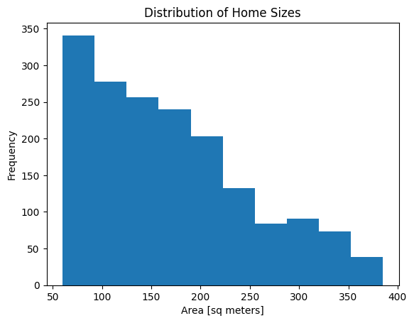

```python
# Use Matplotlib to create histogram of "area_m2"
df['area_m2'].plot(kind="hist")

# Add x-axis label
plt.xlabel("Area [sq meters]")

# Add y-axis label
plt.ylabel("Frequency")

# Add title
plt.title("Distribution of Home Sizes");
```

Looking at our histogram, we can see that "area_m2" skews right. In other words, there are more houses at the lower end of the distribution (50–200m2) than at the higher end (250–400m2). That explains the difference between the mean and the median.

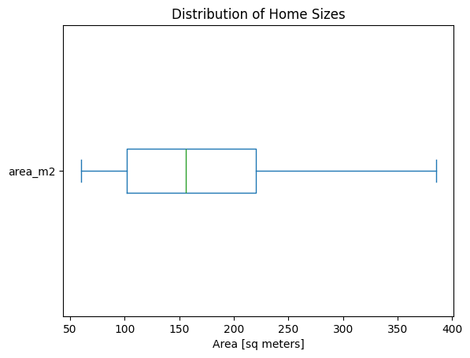

```python
#  create boxplot of "area_m2"
df['area_m2'].plot(kind="box",vert=False)
# Add x-axis label
plt.xlabel("Area [sq meters]")
# Add title
plt.title("Distribution of Home Sizes");
```

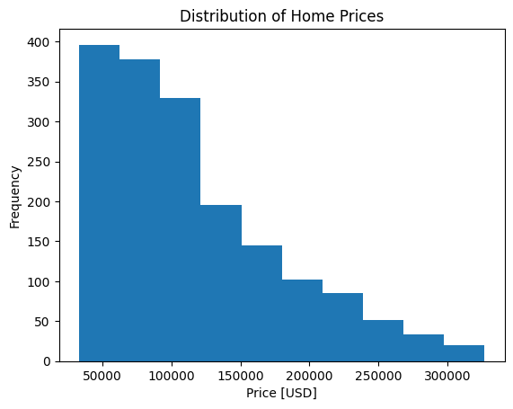

```python
# create histogram of "price_usd"

df['price_usd'].plot(kind="hist")

# Add x-axis label
plt.xlabel("Price [USD]")

# Add y-axis label
plt.ylabel("Frequency")

# Add title
plt.title("Distribution of Home Prices");
```

Looks like "price_usd" is even more skewed than "area_m2". What does this bigger skew look like in a boxplot?

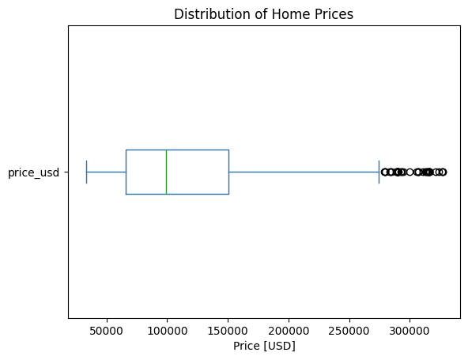

```python
# create boxplot of "price_usd"
df['price_usd'].plot(kind="box",vert=False)
# Add x-axis label
plt.xlabel("Price [USD]")
# Add title
plt.title("Distribution of Home Prices");
```

Excellent! Now that we have a sense of the dataset, let's start answering some research questions about the relationship between house size, price, and location.

# Location or Size: What Influences House Prices in Mexico?

## Research Question 1: Which state has the most expensive real estate market?

Do housing prices vary by state? If so, which are the most expensive states for purchasing a home? During our exploratory data analysis, we used descriptive statistics like mean and median to get an idea of the "typical" house price in Mexico. Now, we need to break that calculation down by state and visualize the results. We know in which state each house is located thanks to the `"state"` column. The next step is to divide our dataset into groups (one per state) and calculate the mean house price for each group.

```python
Mean_price_by_state=df.groupby("state")["price_usd"].mean().sort_values(ascending=False)
Mean_price_by_state
```

```
state
Querétaro                          133955.913417
Guanajuato                         133277.965833
Nuevo León                         129221.985834
Distrito Federal                   128347.267365
Quintana Roo                       128065.415734
Chihuahua                          127073.851184
Jalisco                            123386.472237
Estado de México                   122723.490600
Campeche                           121734.633333
Puebla                             121732.974294
Guerrero                           119854.276015
Sonora                             114547.881798
Morelos                            112697.295615
Aguascalientes                     110543.888316
Baja California Sur                109069.339158
Yucatán                            108580.388526
Chiapas                            104342.313388
Veracruz de Ignacio de la Llave     96928.125254
Hidalgo                             94012.326563
Sinaloa                             93922.152490
Tamaulipas                          93713.386272
San Luis Potosí                     92435.540431
Nayarit                             87378.606842
Tabasco                             82763.586921
Durango                             78034.511729
Zacatecas                           76395.400000
Tlaxcala                            72921.819561
Colima                              65786.646947
Baja California                     63152.431198
Oaxaca                              59681.585000
Name: price_usd, dtype: float64
```

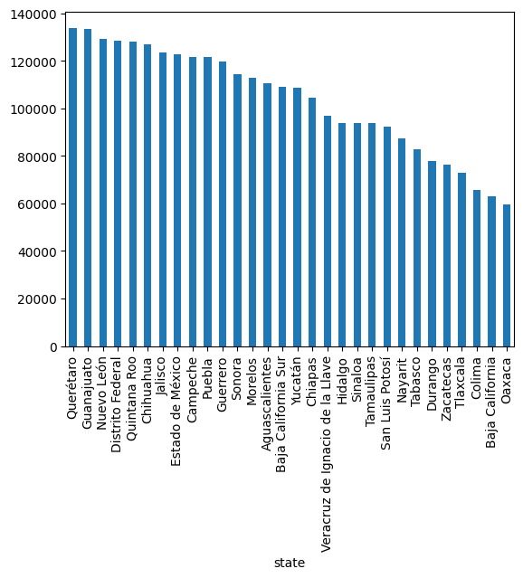

```python
Mean_price_by_state.plot(kind="bar")
```

It seems odd that Querétaro would be the most expensive real estate market in Mexico when, according to recent GDP numbers, it's not in the top 10 state economies. With all the variations in house sizes across states, a better metric to look at would be price per m2. In order to do that, we need to create a new column.

```python
df["price_per_m2"]=df["price_usd"]/df["area_m2"]
df
```

|  | property_type | state | lat | lon | area_m2 | price_usd | price_per_m2 |
| --- | --- | --- | --- | --- | --- | --- | --- |
| 1 | house | Estado de México | 19.560181 | -99.233528 | 150.0 | 67965.56 | 453.103733 |
| 2 | house | Nuevo León | 25.688436 | -100.198807 | 186.0 | 63223.78 | 339.912796 |
| 3 | apartment | Guerrero | 16.767704 | -99.764383 | 82.0 | 84298.37 | 1028.028902 |
| 4 | apartment | Guerrero | 16.829782 | -99.911012 | 150.0 | 94308.80 | 628.725333 |
| 6 | house | Yucatán | 21.052583 | -89.538639 | 205.0 | 105191.37 | 513.128634 |
| ... | ... | ... | ... | ... | ... | ... | ... |
| 696 | house | Jalisco | 20.532264 | -103.484418 | 175.0 | 121178.91 | 692.450914 |
| 697 | house | Morelos | 18.928986 | -99.180215 | 100.0 | 47417.83 | 474.178300 |
| 698 | house | Yucatán | 21.028404 | -89.653006 | 81.0 | 39524.23 | 487.953457 |
| 699 | house | San Luis Potosí | 22.118304 | -101.032194 | 360.0 | 245050.24 | 680.695111 |
| 700 | house | Estado de México | 19.233201 | -99.558519 | 115.0 | 110667.85 | 962.329130 |

1736 rows × 7 columns

```python
Mean_House_Price_by_State=df.groupby("state")["price_per_m2"].mean().sort_values(ascending=False)
Mean_House_Price_by_State
```

```
state
Distrito Federal                   1175.889150
Estado de México                    763.753423
Guerrero                            761.557207
Jalisco                             743.568106
Quintana Roo                        736.455283
Nuevo León                          723.710042
Puebla                              700.701977
Querétaro                           687.227849
Oaxaca                              683.019737
Guanajuato                          672.908100
Baja California Sur                 662.401955
Morelos                             649.383991
Tabasco                             643.503347
Campeche                            601.291762
Nayarit                             599.293638
Baja California                     598.852981
Chihuahua                           591.226745
Chiapas                             560.317147
Sinaloa                             546.536311
Yucatán                             545.889477
Tamaulipas                          541.282079
Veracruz de Ignacio de la Llave     531.536439
San Luis Potosí                     528.501600
Hidalgo                             527.970491
Zacatecas                           492.504078
Tlaxcala                            484.299623
Sonora                              461.845436
Aguascalientes                      449.859135
Durango                             415.447246
Colima                              355.110453
Name: price_per_m2, dtype: float64
```

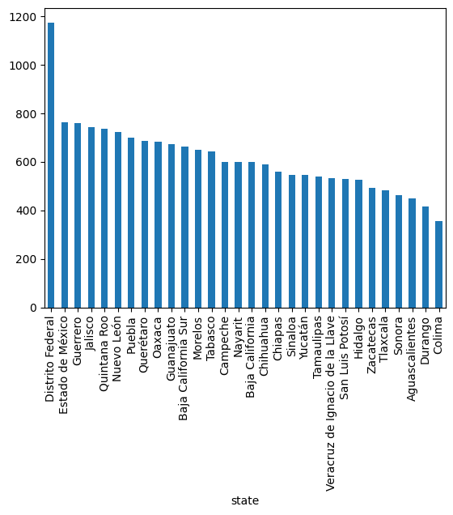

```python
Mean_House_Price_by_State.plot(kind="bar");
```

Now we see that the capital Mexico City (Distrito Federal) is by far the most expensive market. Additionally, many of the top 10 states by GDP are also in the top 10 most expensive real estate markets. So it looks like this bar chart is a more accurate reflection of state real estate markets.